# Global Supermarket Analysis

## OBJECTIVE

This is a global supermarket store data which i have downloaded from kaggle and we can start thinking of some questions about it that we would want to answer

#### Data Exploration

- What is the overall sales trend?
- What is the best selling month?
- What are the most selling product?
- Which is the most preferred ship mode?
- Which are the most profitable category?
- find out from which country the most orders come from?

### Important Libraries

```python
import numpy as np
import pandas as pd
import matplotlib.pyplot as plt
import seaborn as sns
%matplotlib inline
plt.style.use('ggplot')
```

```python
df=pd.read_excel(r"C:\Users\91992\Desktop\global-superstore.xlsx")
```

```python
df.head(5)
```

|  | Row ID | Order ID | Order Date | Ship Date | Ship Mode | Customer ID | Customer Name | Segment | City | State | ... | Product ID | Category | Sub-Category | Product Name | Sales | Quantity | Discount | Profit | Shipping Cost | Order Priority |
| --- | --- | --- | --- | --- | --- | --- | --- | --- | --- | --- | --- | --- | --- | --- | --- | --- | --- | --- | --- | --- | --- |
| 0 | 32298 | CA-2012-124891 | 2012-07-31 | 2012-07-31 | Same Day | RH-19495 | Rick Hansen | Consumer | New York City | New York | ... | TEC-AC-10003033 | Technology | Accessories | Plantronics CS510 - Over-the-Head monaural Wir... | 2309.650 | 7 | 0.0 | 762.1845 | 933.57 | Critical |
| 1 | 26341 | IN-2013-77878 | 2013-02-05 | 2013-02-07 | Second Class | JR-16210 | Justin Ritter | Corporate | Wollongong | New South Wales | ... | FUR-CH-10003950 | Furniture | Chairs | Novimex Executive Leather Armchair, Black | 3709.395 | 9 | 0.1 | -288.7650 | 923.63 | Critical |
| 2 | 25330 | IN-2013-71249 | 2013-10-17 | 2013-10-18 | First Class | CR-12730 | Craig Reiter | Consumer | Brisbane | Queensland | ... | TEC-PH-10004664 | Technology | Phones | Nokia Smart Phone, with Caller ID | 5175.171 | 9 | 0.1 | 919.9710 | 915.49 | Medium |
| 3 | 13524 | ES-2013-1579342 | 2013-01-28 | 2013-01-30 | First Class | KM-16375 | Katherine Murray | Home Office | Berlin | Berlin | ... | TEC-PH-10004583 | Technology | Phones | Motorola Smart Phone, Cordless | 2892.510 | 5 | 0.1 | -96.5400 | 910.16 | Medium |
| 4 | 47221 | SG-2013-4320 | 2013-11-05 | 2013-11-06 | Same Day | RH-9495 | Rick Hansen | Consumer | Dakar | Dakar | ... | TEC-SHA-10000501 | Technology | Copiers | Sharp Wireless Fax, High-Speed | 2832.960 | 8 | 0.0 | 311.5200 | 903.04 | Critical |

5 rows × 24 columns

```python
df.tail(5)
```

|  | Row ID | Order ID | Order Date | Ship Date | Ship Mode | Customer ID | Customer Name | Segment | City | State | ... | Product ID | Category | Sub-Category | Product Name | Sales | Quantity | Discount | Profit | Shipping Cost | Order Priority |
| --- | --- | --- | --- | --- | --- | --- | --- | --- | --- | --- | --- | --- | --- | --- | --- | --- | --- | --- | --- | --- | --- |
| 51285 | 29002 | IN-2014-62366 | 2014-06-19 | 2014-06-19 | Same Day | KE-16420 | Katrina Edelman | Corporate | Kure | Hiroshima | ... | OFF-FA-10000746 | Office Supplies | Fasteners | Advantus Thumb Tacks, 12 Pack | 65.100 | 5 | 0.0 | 4.5000 | 0.010 | Medium |
| 51286 | 35398 | US-2014-102288 | 2014-06-20 | 2014-06-24 | Standard Class | ZC-21910 | Zuschuss Carroll | Consumer | Houston | Texas | ... | OFF-AP-10002906 | Office Supplies | Appliances | Hoover Replacement Belt for Commercial Guardsm... | 0.444 | 1 | 0.8 | -1.1100 | 0.010 | Medium |
| 51287 | 40470 | US-2013-155768 | 2013-12-02 | 2013-12-02 | Same Day | LB-16795 | Laurel Beltran | Home Office | Oxnard | California | ... | OFF-EN-10001219 | Office Supplies | Envelopes | #10- 4 1/8" x 9 1/2" Security-Tint Envelopes | 22.920 | 3 | 0.0 | 11.2308 | 0.010 | High |
| 51288 | 9596 | MX-2012-140767 | 2012-02-18 | 2012-02-22 | Standard Class | RB-19795 | Ross Baird | Home Office | Valinhos | São Paulo | ... | OFF-BI-10000806 | Office Supplies | Binders | Acco Index Tab, Economy | 13.440 | 2 | 0.0 | 2.4000 | 0.003 | Medium |
| 51289 | 6147 | MX-2012-134460 | 2012-05-22 | 2012-05-26 | Second Class | MC-18100 | Mick Crebagga | Consumer | Tipitapa | Managua | ... | OFF-PA-10004155 | Office Supplies | Paper | Eaton Computer Printout Paper, 8.5 x 11 | 61.380 | 3 | 0.0 | 1.8000 | 0.002 | High |

5 rows × 24 columns

```python
df.info()
```

```
<class 'pandas.core.frame.DataFrame'>
RangeIndex: 51290 entries, 0 to 51289
Data columns (total 24 columns):
 #   Column          Non-Null Count  Dtype
---  ------          --------------  -----
 0   Row ID          51290 non-null  int64
 1   Order ID        51290 non-null  object
 2   Order Date      51290 non-null  datetime64[ns]
 3   Ship Date       51290 non-null  datetime64[ns]
 4   Ship Mode       51290 non-null  object
 5   Customer ID     51290 non-null  object
 6   Customer Name   51290 non-null  object
 7   Segment         51290 non-null  object
 8   City            51290 non-null  object
 9   State           51290 non-null  object
```

[output cut: 16 more lines]

```python
df.isnull().sum() # finding missing values in dataset
```

```
Row ID                0
Order ID              0
Order Date            0
Ship Date             0
Ship Mode             0
Customer ID           0
Customer Name         0
Segment               0
City                  0
State                 0
Country               0
Postal Code       41296
Market                0
Region                0
Product ID            0
Category              0
Sub-Category          0
Product Name          0
Sales                 0
Quantity              0
Discount              0
Profit                0
Shipping Cost         0
Order Priority        0
dtype: int64
```

```python
df.Market.value_counts()
```

```
APAC      11002
LATAM     10294
EU        10000
US         9994
EMEA       5029
Africa     4587
Canada      384
Name: Market, dtype: int64
```

```python
df.Region.value_counts()
```

```
Central           11117
South              6645
EMEA               5029
North              4785
Africa             4587
Oceania            3487
West               3203
Southeast Asia     3129
East               2848
North Asia         2338
Central Asia       2048
Caribbean          1690
Canada              384
Name: Region, dtype: int64
```

```python
df.columns # clean the data
```

```
Index(['Row ID', 'Order ID', 'Order Date', 'Ship Date', 'Ship Mode',
       'Customer ID', 'Customer Name', 'Segment', 'City', 'State', 'Country',
       'Postal Code', 'Market', 'Region', 'Product ID', 'Category',
       'Sub-Category', 'Product Name', 'Sales', 'Quantity', 'Discount',
       'Profit', 'Shipping Cost', 'Order Priority'],
      dtype='object')
```

```python
df.drop(columns=['Row ID','Order ID','Ship Date','Postal Code'],axis=1,inplace=True)
```

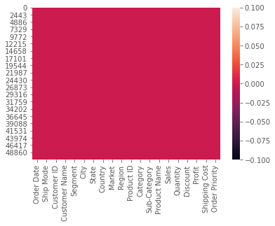

```python
sns.heatmap(df.isnull())
```

```python
df.describe()
```

|  | Sales | Quantity | Discount | Profit | Shipping Cost |
| --- | --- | --- | --- | --- | --- |
| count | 51290.000000 | 51290.000000 | 51290.000000 | 51290.000000 | 51290.000000 |
| mean | 246.490581 | 3.476545 | 0.142908 | 28.610982 | 26.375818 |
| std | 487.565361 | 2.278766 | 0.212280 | 174.340972 | 57.296810 |
| min | 0.444000 | 1.000000 | 0.000000 | -6599.978000 | 0.002000 |
| 25% | 30.758625 | 2.000000 | 0.000000 | 0.000000 | 2.610000 |
| 50% | 85.053000 | 3.000000 | 0.000000 | 9.240000 | 7.790000 |
| 75% | 251.053200 | 5.000000 | 0.200000 | 36.810000 | 24.450000 |
| max | 22638.480000 | 14.000000 | 0.850000 | 8399.976000 | 933.570000 |

```python
num=df._get_numeric_data()
num[num<0]=0
```

```python
df.describe()  # Statistical Analysis
```

|  | Sales | Quantity | Discount | Profit | Shipping Cost |
| --- | --- | --- | --- | --- | --- |
| count | 51290.000000 | 51290.000000 | 51290.000000 | 51290.000000 | 51290.000000 |
| mean | 246.490581 | 3.476545 | 0.142908 | 46.560800 | 26.375818 |
| std | 487.565361 | 2.278766 | 0.212280 | 138.734076 | 57.296810 |
| min | 0.444000 | 1.000000 | 0.000000 | 0.000000 | 0.002000 |
| 25% | 30.758625 | 2.000000 | 0.000000 | 0.000000 | 2.610000 |
| 50% | 85.053000 | 3.000000 | 0.000000 | 9.240000 | 7.790000 |
| 75% | 251.053200 | 5.000000 | 0.200000 | 36.810000 | 24.450000 |
| max | 22638.480000 | 14.000000 | 0.850000 | 8399.976000 | 933.570000 |

### let's jump to Exploratory Data Analysis

-

#### Sales Analysis

```python
df['Order Date'].min()
```

```
Timestamp('2011-01-01 00:00:00')
```

```python
df['Order Date'].max()
```

```
Timestamp('2014-12-31 00:00:00')
```

```python
# Using lambda function and extracting date into month-year
df.insert(1,'month year',df['Order Date'].apply(lambda x:x.strftime('%Y-%m')))
```

```python
df.insert(2,'month',df['Order Date'].dt.month)
```

```python
df.insert(3,'year',df['Order Date'].dt.year)
```

```python
df.head(5)
```

|  | Order Date | month year | month | year | Ship Mode | Customer ID | Customer Name | Segment | City | State | ... | Product ID | Category | Sub-Category | Product Name | Sales | Quantity | Discount | Profit | Shipping Cost | Order Priority |
| --- | --- | --- | --- | --- | --- | --- | --- | --- | --- | --- | --- | --- | --- | --- | --- | --- | --- | --- | --- | --- | --- |
| 0 | 2012-07-31 | 2012-07 | 7 | 2012 | Same Day | RH-19495 | Rick Hansen | Consumer | New York City | New York | ... | TEC-AC-10003033 | Technology | Accessories | Plantronics CS510 - Over-the-Head monaural Wir... | 2309.650 | 7 | 0.0 | 762.1845 | 933.57 | Critical |
| 1 | 2013-02-05 | 2013-02 | 2 | 2013 | Second Class | JR-16210 | Justin Ritter | Corporate | Wollongong | New South Wales | ... | FUR-CH-10003950 | Furniture | Chairs | Novimex Executive Leather Armchair, Black | 3709.395 | 9 | 0.1 | 0.0000 | 923.63 | Critical |
| 2 | 2013-10-17 | 2013-10 | 10 | 2013 | First Class | CR-12730 | Craig Reiter | Consumer | Brisbane | Queensland | ... | TEC-PH-10004664 | Technology | Phones | Nokia Smart Phone, with Caller ID | 5175.171 | 9 | 0.1 | 919.9710 | 915.49 | Medium |
| 3 | 2013-01-28 | 2013-01 | 1 | 2013 | First Class | KM-16375 | Katherine Murray | Home Office | Berlin | Berlin | ... | TEC-PH-10004583 | Technology | Phones | Motorola Smart Phone, Cordless | 2892.510 | 5 | 0.1 | 0.0000 | 910.16 | Medium |
| 4 | 2013-11-05 | 2013-11 | 11 | 2013 | Same Day | RH-9495 | Rick Hansen | Consumer | Dakar | Dakar | ... | TEC-SHA-10000501 | Technology | Copiers | Sharp Wireless Fax, High-Speed | 2832.960 | 8 | 0.0 | 311.5200 | 903.04 | Critical |

5 rows × 23 columns

```python
sales=df.groupby('month year')['Sales'].sum().reset_index()
```

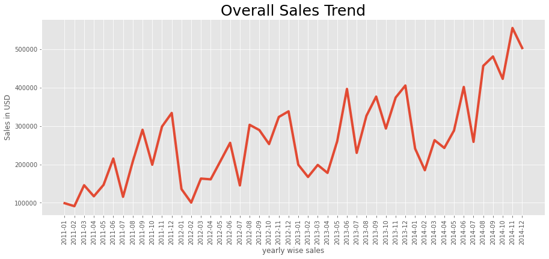

```python
plt.figure(figsize=(15,6))
plt.plot(sales['month year'],sales['Sales'],linewidth=4)
plt.xticks(rotation='vertical')
plt.ylabel('Sales in USD')
plt.xlabel('yearly wise sales')
plt.title('Overall Sales Trend',size=25)
plt.show()
```

**Observation** :- As we can see in this graph that sales are increasing and company overall is growing.

```python
monthly_sales=np.round(df.groupby('month')['Sales'].sum(),2).reset_index()
```

```python
monthly_sales
```

|  | month | Sales |
| --- | --- | --- |
| 0 | 1 | 675133.67 |
| 1 | 2 | 543739.38 |
| 2 | 3 | 770500.94 |
| 3 | 4 | 698561.21 |
| 4 | 5 | 904012.34 |
| 5 | 6 | 1269716.75 |
| 6 | 7 | 749381.84 |
| 7 | 8 | 1293833.17 |
| 8 | 9 | 1437380.11 |
| 9 | 10 | 1168184.39 |
| 10 | 11 | 1551277.34 |
| 11 | 12 | 1580780.77 |

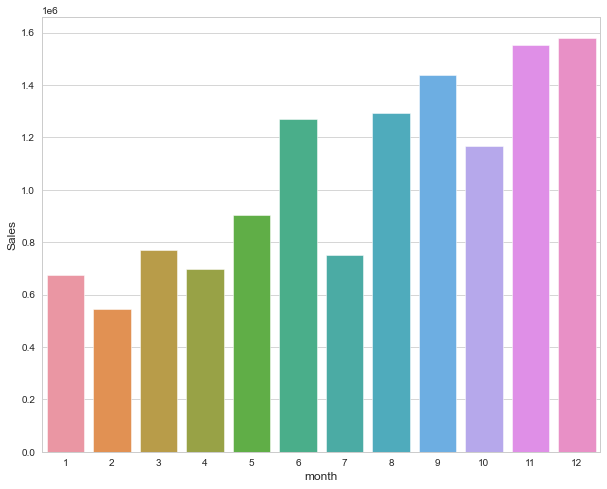

```python
plt.figure(figsize=(10,8))
sns.set_style('whitegrid')
sns.barplot(x='month',y='Sales',data=monthly_sales)
```

- **Observation** :- As we can see that most of the people are purchasing products in last 5 months

```python
# Total Yearly Sales Analysis
Total_yearly_sales=np.round(df.groupby('year')['Sales'].sum(),2).reset_index()
```

```python
Total_yearly_sales
```

|  | year | Sales |
| --- | --- | --- |
| 0 | 2011 | 2259450.90 |
| 1 | 2012 | 2677438.69 |
| 2 | 2013 | 3405746.45 |
| 3 | 2014 | 4299865.87 |

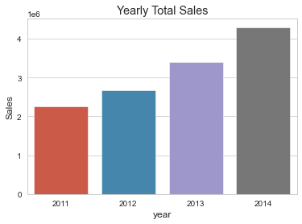

```python
sns.set_style('whitegrid')
sns.barplot(x='year',y='Sales',data=Total_yearly_sales).set_title('Yearly Total Sales')
```

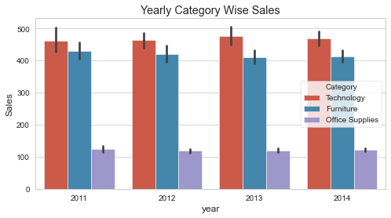

```python
plt.figure(figsize=(8,4))
sns.barplot(x='year',y='Sales',data=df,hue='Category').set_title('Yearly Category Wise Sales')
plt.show()
```

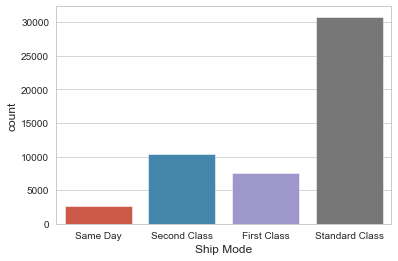

```python
sns.countplot(x=df['Ship Mode'])
```

```python
df.columns
```

```
Index(['Order Date', 'month year', 'month', 'year', 'Ship Mode', 'Customer ID',
       'Customer Name', 'Segment', 'City', 'State', 'Country', 'Market',
       'Region', 'Product ID', 'Category', 'Sub-Category', 'Product Name',
       'Sales', 'Quantity', 'Discount', 'Profit', 'Shipping Cost',
       'Order Priority'],
      dtype='object')
```

```python
df['Market'].value_counts()
```

```
APAC      11002
LATAM     10294
EU        10000
US         9994
EMEA       5029
Africa     4587
Canada      384
Name: Market, dtype: int64
```

```python
df['Region'].value_counts()
```

```
Central           11117
South              6645
EMEA               5029
North              4785
Africa             4587
Oceania            3487
West               3203
Southeast Asia     3129
East               2848
North Asia         2338
Central Asia       2048
Caribbean          1690
Canada              384
Name: Region, dtype: int64
```

```python
# market capture
coun=df['Market'].value_counts().index
```

```python
val=df['Market'].value_counts().values
```

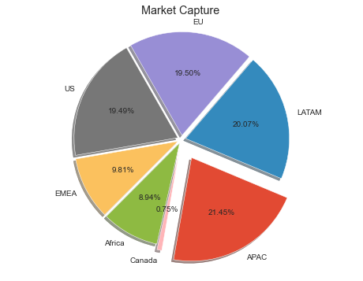

```python
def func(pct): # most profitable bussiness in 2014 year comparison to other
  return "{:1.2f}%".format(pct)
plt.subplots(figsize =(8, 6))
plt.pie(val,labels=coun,autopct=lambda pct: func(pct),explode=[0.2,0.04,0.04,0.04,0.04,0.04,0.09], shadow=True,startangle=260)
plt.axis('equal')
plt.title('Market Capture ')
plt.show()
```

```python
customer_segment=df.groupby('Segment')['Quantity'].sum().reset_index()
```

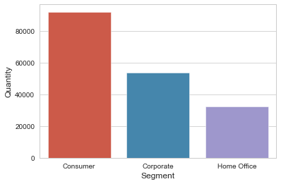

```python
sns.barplot(x=customer_segment['Segment'],y=customer_segment['Quantity'])
```

**Region wise sales**

```python
df['Region'].value_counts()
```

```
Central           11117
South              6645
EMEA               5029
North              4785
Africa             4587
Oceania            3487
West               3203
Southeast Asia     3129
East               2848
North Asia         2338
Central Asia       2048
Caribbean          1690
Canada              384
Name: Region, dtype: int64
```

```python
maps=df.groupby('Region')['Sales'].sum().reset_index()
```

```python
reg=np.round(df.groupby('Region')['Sales'].sum(),2).reset_index()
```

```python
reg
```

|  | Region | Sales |
| --- | --- | --- |
| 0 | Africa | 783773.21 |
| 1 | Canada | 66928.17 |
| 2 | Caribbean | 324280.86 |
| 3 | Central | 2822302.52 |
| 4 | Central Asia | 752826.57 |
| 5 | EMEA | 806161.31 |
| 6 | East | 678781.24 |
| 7 | North | 1248165.60 |
| 8 | North Asia | 848309.78 |
| 9 | Oceania | 1100184.61 |
| 10 | South | 1600907.04 |
| 11 | Southeast Asia | 884423.17 |
| 12 | West | 725457.82 |

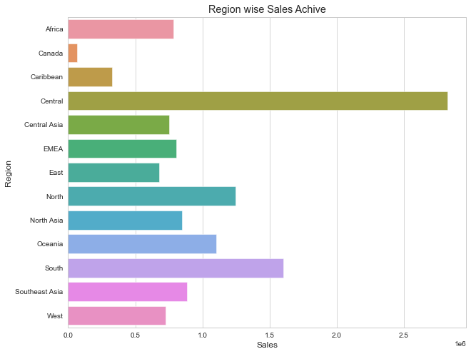

```python
plt.figure(figsize=(10,8))
ax=sns.barplot(x=reg['Sales'],y=reg['Region']).set_title('Region wise Sales Achive')
```

-**Observation** : As we can see The maximum sale has taken place in the centrel region and in Canada and other regions, we should give advertisements and discounts

### Profit Analysis

```python
df.columns
```

```
Index(['Order Date', 'month year', 'month', 'year', 'Ship Mode', 'Customer ID',
       'Customer Name', 'Segment', 'City', 'State', 'Country', 'Market',
       'Region', 'Product ID', 'Category', 'Sub-Category', 'Product Name',
       'Sales', 'Quantity', 'Discount', 'Profit', 'Shipping Cost',
       'Order Priority'],
      dtype='object')
```

```python
pro=np.round(df.groupby('year')['Profit'].sum()).reset_index()
```

```python
pro
```

|  | year | Profit |
| --- | --- | --- |
| 0 | 2011 | 418249.0 |
| 1 | 2012 | 502758.0 |
| 2 | 2013 | 652842.0 |
| 3 | 2014 | 814254.0 |

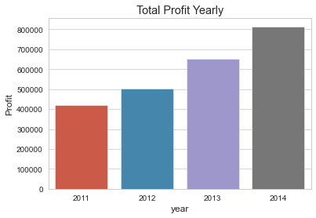

```python
sns.barplot(x=pro['year'],y=pro['Profit'])
plt.title('Total Profit Yearly')
plt.show()
```

```python
# Top 10 profitable Country
s=df.groupby('Country')['Profit'].sum().sort_values(ascending=False).reset_index()
```

```python
k=s['Country'].unique()
```

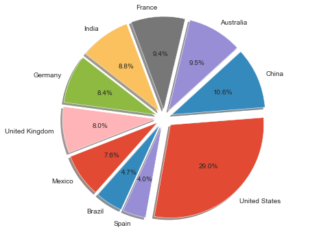

```python
def func(pct): # most profitable bussiness from United States comparison to other country
  return "{:0.1f}%".format(pct)
plt.subplots(figsize =(8, 6))
plt.pie(s['Profit'][:10],labels=k[:10],autopct=lambda pct: func(pct),explode=[0.1,0.09,0.09,0.09,0.09,0.09,0.09,0.09,0.09,0.09], shadow=True,startangle=260)
plt.axis('equal')
plt.show()
```

- **Observation** <> Most profitable business from United States comparison to other country

### Product Analysis

```python
df.columns
```

```
Index(['Order Date', 'month year', 'month', 'year', 'Ship Mode', 'Customer ID',
       'Customer Name', 'Segment', 'City', 'State', 'Country', 'Market',
       'Region', 'Product ID', 'Category', 'Sub-Category', 'Product Name',
       'Sales', 'Quantity', 'Discount', 'Profit', 'Shipping Cost',
       'Order Priority'],
      dtype='object')
```

```python
profitable_cat=df.groupby(['Category','Sub-Category']).sum()['Profit'].reset_index()
```

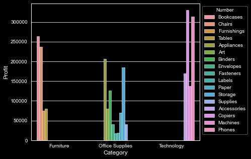

```python
plt.figure(figsize=(6,5))
sns.barplot(x='Category',y='Profit',hue='Sub-Category',data=profitable_cat)
plt.legend(title = 'Number', bbox_to_anchor = (1, 1))
```

#### find out from which country the most orders come from?

```python
highest_order=df.groupby(['Country'])['Quantity'].sum().sort_values(ascending=False).reset_index().head(10)
```

```python
highest_order
```

|  | Country | Quantity |
| --- | --- | --- |
| 0 | United States | 37873 |
| 1 | France | 10804 |
| 2 | Australia | 10673 |
| 3 | Mexico | 10011 |
| 4 | Germany | 7745 |
| 5 | China | 7081 |
| 6 | United Kingdom | 6161 |
| 7 | Brazil | 6148 |
| 8 | India | 5758 |
| 9 | Indonesia | 5237 |

```python
from wordcloud import WordCloud
```

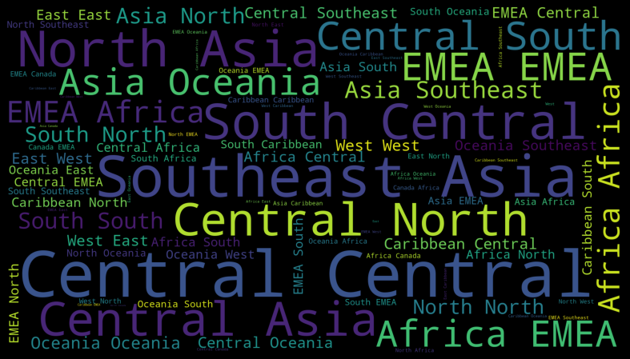

```python
plt.subplots(figsize=(100,8))
wordcloud = WordCloud(background_color='Black',width=1920,height=1080).generate(" ".join(df['Region']))
plt.imshow(wordcloud)
plt.axis('off')
plt.show()
```

## Thank you very much for viewing my project. I hope you enjoy this project, if anything is wrong with this project you can share your review with me.